# Happy Analysis

Kyra Kong

2023-02-18

# Load New Package

```r
#install.packages("shiny")
#install.packages("shinydashboard")
```

#Load Programs

```r
library(tidyverse)
library(naniar)
library(janitor)
library(here)
library(shiny)
library(shinydashboard)
```

```r
library(ggplot2)
library(ggthemes)
```

```r
getwd()
```

```
## [1] "C:/Users/merma/OneDrive/Desktop/happy/happiness_finder/happy_project/Kyra"
```

#Load 2021 Data

```r
happy_2021 <-read.csv("/Users/merma/OneDrive/Desktop/happy/happiness_finder/happy_project/happiness_data/2021.csv") %>% clean_names()
happy_2021
```

```
##                  country_name                 regional_indicator ladder_score
## 1                     Finland                     Western Europe        7.842
## 2                     Denmark                     Western Europe        7.620
## 3                 Switzerland                     Western Europe        7.571
## 4                     Iceland                     Western Europe        7.554
## 5                 Netherlands                     Western Europe        7.464
## 6                      Norway                     Western Europe        7.392
## 7                      Sweden                     Western Europe        7.363
## 8                  Luxembourg                     Western Europe        7.324
## 9                 New Zealand              North America and ANZ        7.277
## 10                    Austria                     Western Europe        7.268
## 11                  Australia              North America and ANZ        7.183
## 12                     Israel       Middle East and North Africa        7.157
## 13                    Germany                     Western Europe        7.155
## 14                     Canada              North America and ANZ        7.103
```

[output cut: 1185 more lines]

#Add 2021 Year Column

```r
happy_2021$year <- "2021"
happy_2021
```

```
##                  country_name                 regional_indicator ladder_score
## 1                     Finland                     Western Europe        7.842
## 2                     Denmark                     Western Europe        7.620
## 3                 Switzerland                     Western Europe        7.571
## 4                     Iceland                     Western Europe        7.554
## 5                 Netherlands                     Western Europe        7.464
## 6                      Norway                     Western Europe        7.392
## 7                      Sweden                     Western Europe        7.363
## 8                  Luxembourg                     Western Europe        7.324
## 9                 New Zealand              North America and ANZ        7.277
## 10                    Austria                     Western Europe        7.268
## 11                  Australia              North America and ANZ        7.183
## 12                     Israel       Middle East and North Africa        7.157
## 13                    Germany                     Western Europe        7.155
## 14                     Canada              North America and ANZ        7.103
```

[output cut: 1185 more lines]

#Load 2020 Data

```r
happy_2020 <-read.csv("/users/merma/OneDrive/Desktop/happy/happiness_finder/happy_project/happiness_data/2020.csv") %>% clean_names()
happy_2020
```

```
##                  country_name                 regional_indicator ladder_score
## 1                     Finland                     Western Europe       7.8087
## 2                     Denmark                     Western Europe       7.6456
## 3                 Switzerland                     Western Europe       7.5599
## 4                     Iceland                     Western Europe       7.5045
## 5                      Norway                     Western Europe       7.4880
## 6                 Netherlands                     Western Europe       7.4489
## 7                      Sweden                     Western Europe       7.3535
## 8                 New Zealand              North America and ANZ       7.2996
## 9                     Austria                     Western Europe       7.2942
## 10                 Luxembourg                     Western Europe       7.2375
## 11                     Canada              North America and ANZ       7.2321
## 12                  Australia              North America and ANZ       7.2228
## 13             United Kingdom                     Western Europe       7.1645
## 14                     Israel       Middle East and North Africa       7.1286
```

[output cut: 1217 more lines]

#Add 2020 Year Column

```r
happy_2020$year <-"2020"
happy_2020
```

```
##                  country_name                 regional_indicator ladder_score
## 1                     Finland                     Western Europe       7.8087
## 2                     Denmark                     Western Europe       7.6456
## 3                 Switzerland                     Western Europe       7.5599
## 4                     Iceland                     Western Europe       7.5045
## 5                      Norway                     Western Europe       7.4880
## 6                 Netherlands                     Western Europe       7.4489
## 7                      Sweden                     Western Europe       7.3535
## 8                 New Zealand              North America and ANZ       7.2996
## 9                     Austria                     Western Europe       7.2942
## 10                 Luxembourg                     Western Europe       7.2375
## 11                     Canada              North America and ANZ       7.2321
## 12                  Australia              North America and ANZ       7.2228
## 13             United Kingdom                     Western Europe       7.1645
## 14                     Israel       Middle East and North Africa       7.1286
```

[output cut: 1217 more lines]

#Retrieve Names

```r
names(happy_2020)
```

```
##  [1] "country_name"
##  [2] "regional_indicator"
##  [3] "ladder_score"
##  [4] "standard_error_of_ladder_score"
##  [5] "upperwhisker"
##  [6] "lowerwhisker"
##  [7] "logged_gdp_per_capita"
##  [8] "social_support"
##  [9] "healthy_life_expectancy"
## [10] "freedom_to_make_life_choices"
## [11] "generosity"
## [12] "perceptions_of_corruption"
## [13] "ladder_score_in_dystopia"
## [14] "explained_by_log_gdp_per_capita"
## [15] "explained_by_social_support"
## [16] "explained_by_healthy_life_expectancy"
## [17] "explained_by_freedom_to_make_life_choices"
## [18] "explained_by_generosity"
## [19] "explained_by_perceptions_of_corruption"
## [20] "dystopia_residual"
## [21] "year"
```

```r
names(happy_2021)
```

```
##  [1] "country_name"
##  [2] "regional_indicator"
##  [3] "ladder_score"
##  [4] "standard_error_of_ladder_score"
##  [5] "upperwhisker"
##  [6] "lowerwhisker"
##  [7] "logged_gdp_per_capita"
##  [8] "social_support"
##  [9] "healthy_life_expectancy"
## [10] "freedom_to_make_life_choices"
## [11] "generosity"
## [12] "perceptions_of_corruption"
## [13] "ladder_score_in_dystopia"
## [14] "explained_by_log_gdp_per_capita"
## [15] "explained_by_social_support"
## [16] "explained_by_healthy_life_expectancy"
## [17] "explained_by_freedom_to_make_life_choices"
## [18] "explained_by_generosity"
## [19] "explained_by_perceptions_of_corruption"
## [20] "dystopia_residual"
## [21] "year"
```

#Merge Data Sets

```r
merged_happy <-rbind(happy_2021,happy_2020)
```

```r
merged_happy
```

```
##                  country_name                 regional_indicator ladder_score
## 1                     Finland                     Western Europe       7.8420
## 2                     Denmark                     Western Europe       7.6200
## 3                 Switzerland                     Western Europe       7.5710
## 4                     Iceland                     Western Europe       7.5540
## 5                 Netherlands                     Western Europe       7.4640
## 6                      Norway                     Western Europe       7.3920
## 7                      Sweden                     Western Europe       7.3630
## 8                  Luxembourg                     Western Europe       7.3240
## 9                 New Zealand              North America and ANZ       7.2770
## 10                    Austria                     Western Europe       7.2680
## 11                  Australia              North America and ANZ       7.1830
## 12                     Israel       Middle East and North Africa       7.1570
## 13                    Germany                     Western Europe       7.1550
## 14                     Canada              North America and ANZ       7.1030
```

[output cut: 2409 more lines]

#Make New CSV File

```r
write.csv(merged_happy,"merged_happy.csv",row.names = F)
```

#Retrieve Newly Merged Data

```r
n_happy <- read.csv("/users/merma/OneDrive/Desktop/happy/happiness_finder/happy_project/happiness_data/merged_happy.csv")
n_happy
```

```
##                  country_name                 regional_indicator ladder_score
## 1                     Finland                     Western Europe       7.8420
## 2                     Denmark                     Western Europe       7.6200
## 3                 Switzerland                     Western Europe       7.5710
## 4                     Iceland                     Western Europe       7.5540
## 5                 Netherlands                     Western Europe       7.4640
## 6                      Norway                     Western Europe       7.3920
## 7                      Sweden                     Western Europe       7.3630
## 8                  Luxembourg                     Western Europe       7.3240
## 9                 New Zealand              North America and ANZ       7.2770
## 10                    Austria                     Western Europe       7.2680
## 11                  Australia              North America and ANZ       7.1830
## 12                     Israel       Middle East and North Africa       7.1570
## 13                    Germany                     Western Europe       7.1550
## 14                     Canada              North America and ANZ       7.1030
```

[output cut: 2409 more lines]

#Structural Analysis of New Data

```r
names(n_happy)
```

```
##  [1] "country_name"
##  [2] "regional_indicator"
##  [3] "ladder_score"
##  [4] "standard_error_of_ladder_score"
##  [5] "upperwhisker"
##  [6] "lowerwhisker"
##  [7] "logged_gdp_per_capita"
##  [8] "social_support"
##  [9] "healthy_life_expectancy"
## [10] "freedom_to_make_life_choices"
## [11] "generosity"
## [12] "perceptions_of_corruption"
## [13] "ladder_score_in_dystopia"
## [14] "explained_by_log_gdp_per_capita"
## [15] "explained_by_social_support"
## [16] "explained_by_healthy_life_expectancy"
## [17] "explained_by_freedom_to_make_life_choices"
## [18] "explained_by_generosity"
## [19] "explained_by_perceptions_of_corruption"
## [20] "dystopia_residual"
## [21] "year"
```

```r
glimpse(n_happy)
```

```
## Rows: 302
## Columns: 21
## $ country_name                              <chr> "Finland", "Denmark", "Switz…
## $ regional_indicator                        <chr> "Western Europe", "Western E…
## $ ladder_score                              <dbl> 7.842, 7.620, 7.571, 7.554, …
## $ standard_error_of_ladder_score            <dbl> 0.032, 0.035, 0.036, 0.059, …
## $ upperwhisker                              <dbl> 7.904, 7.687, 7.643, 7.670, …
## $ lowerwhisker                              <dbl> 7.780, 7.552, 7.500, 7.438, …
## $ logged_gdp_per_capita                     <dbl> 10.775, 10.933, 11.117, 10.8…
## $ social_support                            <dbl> 0.954, 0.954, 0.942, 0.983, …
## $ healthy_life_expectancy                   <dbl> 72.000, 72.700, 74.400, 73.0…
## $ freedom_to_make_life_choices              <dbl> 0.949, 0.946, 0.919, 0.955, …
## $ generosity                                <dbl> -0.098, 0.030, 0.025, 0.160,…
## $ perceptions_of_corruption                 <dbl> 0.186, 0.179, 0.292, 0.673, …
## $ ladder_score_in_dystopia                  <dbl> 2.43, 2.43, 2.43, 2.43, 2.43…
## $ explained_by_log_gdp_per_capita           <dbl> 1.446, 1.502, 1.566, 1.482, …
## $ explained_by_social_support               <dbl> 1.106, 1.108, 1.079, 1.172, …
## $ explained_by_healthy_life_expectancy      <dbl> 0.741, 0.763, 0.816, 0.772, …
## $ explained_by_freedom_to_make_life_choices <dbl> 0.691, 0.686, 0.653, 0.698, …
## $ explained_by_generosity                   <dbl> 0.124, 0.208, 0.204, 0.293, …
## $ explained_by_perceptions_of_corruption    <dbl> 0.481, 0.485, 0.413, 0.170, …
## $ dystopia_residual                         <dbl> 3.253, 2.868, 2.839, 2.967, …
## $ year                                      <int> 2021, 2021, 2021, 2021, 2021…
```

#NA Summary

```r
naniar::miss_var_summary(n_happy)
```

```
## # A tibble: 21 × 3
##    variable                       n_miss pct_miss
##    <chr>                           <int>    <dbl>
##  1 country_name                        0        0
##  2 regional_indicator                  0        0
##  3 ladder_score                        0        0
##  4 standard_error_of_ladder_score      0        0
##  5 upperwhisker                        0        0
##  6 lowerwhisker                        0        0
##  7 logged_gdp_per_capita               0        0
##  8 social_support                      0        0
##  9 healthy_life_expectancy             0        0
## 10 freedom_to_make_life_choices        0        0
## # … with 11 more rows
```

# Create New Data Frame(Specified the Factors We Want to Analyze)

```r
narrow <- n_happy %>%
  select(country_name,ladder_score,year,social_support,healthy_life_expectancy,freedom_to_make_life_choices,generosity,perceptions_of_corruption,logged_gdp_per_capita, dystopia_residual)
narrow
```

```
##                  country_name ladder_score year social_support
## 1                     Finland       7.8420 2021      0.9540000
## 2                     Denmark       7.6200 2021      0.9540000
## 3                 Switzerland       7.5710 2021      0.9420000
## 4                     Iceland       7.5540 2021      0.9830000
## 5                 Netherlands       7.4640 2021      0.9420000
## 6                      Norway       7.3920 2021      0.9540000
## 7                      Sweden       7.3630 2021      0.9340000
## 8                  Luxembourg       7.3240 2021      0.9080000
## 9                 New Zealand       7.2770 2021      0.9480000
## 10                    Austria       7.2680 2021      0.9340000
## 11                  Australia       7.1830 2021      0.9400000
## 12                     Israel       7.1570 2021      0.9390000
## 13                    Germany       7.1550 2021      0.9030000
## 14                     Canada       7.1030 2021      0.9260000
```

[output cut: 894 more lines]

#2020 Narrow(Puts more focus on the stats from 2020)

```r
tw_narrow<-
  narrow%>%
  filter(year=="2020")
tw_narrow
```

```
##                  country_name ladder_score year social_support
## 1                     Finland       7.8087 2020      0.9543297
## 2                     Denmark       7.6456 2020      0.9559908
## 3                 Switzerland       7.5599 2020      0.9428466
## 4                     Iceland       7.5045 2020      0.9746696
## 5                      Norway       7.4880 2020      0.9524866
## 6                 Netherlands       7.4489 2020      0.9391388
## 7                      Sweden       7.3535 2020      0.9263112
## 8                 New Zealand       7.2996 2020      0.9491190
## 9                     Austria       7.2942 2020      0.9280459
## 10                 Luxembourg       7.2375 2020      0.9069122
## 11                     Canada       7.2321 2020      0.9271767
## 12                  Australia       7.2228 2020      0.9448546
## 13             United Kingdom       7.1645 2020      0.9366828
## 14                     Israel       7.1286 2020      0.9135712
```

[output cut: 447 more lines]

```r
names(tw_narrow)
```

```
##  [1] "country_name"                 "ladder_score"
##  [3] "year"                         "social_support"
##  [5] "healthy_life_expectancy"      "freedom_to_make_life_choices"
##  [7] "generosity"                   "perceptions_of_corruption"
##  [9] "logged_gdp_per_capita"        "dystopia_residual"
```

#Create Stacked Bar Plot for 2020 Data

```r
names(tw_narrow)
```

```
##  [1] "country_name"                 "ladder_score"
##  [3] "year"                         "social_support"
##  [5] "healthy_life_expectancy"      "freedom_to_make_life_choices"
##  [7] "generosity"                   "perceptions_of_corruption"
##  [9] "logged_gdp_per_capita"        "dystopia_residual"
```

#Reorder Dataframe involves pivoting longer for the 2020 data to create a bar plot.

```r
reorder <- tw_narrow %>%
  group_by(country_name) %>%
pivot_longer (-c(country_name,year,ladder_score),
  names_to= "Factors",
  values_to="Score") %>%
  clean_names()
reorder
```

```
## # A tibble: 1,071 × 5
## # Groups:   country_name [153]
##    country_name ladder_score  year factors                        score
##    <chr>               <dbl> <int> <chr>                          <dbl>
##  1 Finland              7.81  2020 social_support                0.954
##  2 Finland              7.81  2020 healthy_life_expectancy      71.9
##  3 Finland              7.81  2020 freedom_to_make_life_choices  0.949
##  4 Finland              7.81  2020 generosity                   -0.0595
##  5 Finland              7.81  2020 perceptions_of_corruption     0.195
##  6 Finland              7.81  2020 logged_gdp_per_capita        10.6
##  7 Finland              7.81  2020 dystopia_residual             2.76
##  8 Denmark              7.65  2020 social_support                0.956
##  9 Denmark              7.65  2020 healthy_life_expectancy      72.4
## 10 Denmark              7.65  2020 freedom_to_make_life_choices  0.951
## # … with 1,061 more rows
```

#Code for plot(this is specific to tw_narrow(2020 data))

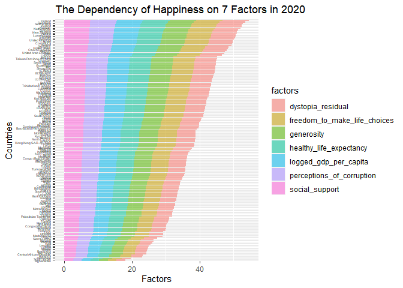

```r
reorder %>%
  group_by(country_name) %>%
 ggplot(aes(x=reorder(country_name,ladder_score),country_name,y=ladder_score, fill=factors))+
   geom_col(alpha=0.55)+
  coord_flip()+
  labs(title = "The Dependency of Happiness on 7 Factors in 2020", x= "Countries", y="Factors")+
  theme(axis.text.y =element_text(size=3.5))
```

```r
t1_narrow<-
  narrow%>%
  filter(year=="2021")
t1_narrow
```

```
##                  country_name ladder_score year social_support
## 1                     Finland        7.842 2021          0.954
## 2                     Denmark        7.620 2021          0.954
## 3                 Switzerland        7.571 2021          0.942
## 4                     Iceland        7.554 2021          0.983
## 5                 Netherlands        7.464 2021          0.942
## 6                      Norway        7.392 2021          0.954
## 7                      Sweden        7.363 2021          0.934
## 8                  Luxembourg        7.324 2021          0.908
## 9                 New Zealand        7.277 2021          0.948
## 10                    Austria        7.268 2021          0.934
## 11                  Australia        7.183 2021          0.940
## 12                     Israel        7.157 2021          0.939
## 13                    Germany        7.155 2021          0.903
## 14                     Canada        7.103 2021          0.926
```

[output cut: 435 more lines]

```r
revamp <- t1_narrow %>%
  group_by(country_name) %>%
pivot_longer (-c(country_name,year,ladder_score),
  names_to= "Factors",
  values_to="Score") %>%
  clean_names()
revamp
```

```
## # A tibble: 1,043 × 5
## # Groups:   country_name [149]
##    country_name ladder_score  year factors                       score
##    <chr>               <dbl> <int> <chr>                         <dbl>
##  1 Finland              7.84  2021 social_support                0.954
##  2 Finland              7.84  2021 healthy_life_expectancy      72
##  3 Finland              7.84  2021 freedom_to_make_life_choices  0.949
##  4 Finland              7.84  2021 generosity                   -0.098
##  5 Finland              7.84  2021 perceptions_of_corruption     0.186
##  6 Finland              7.84  2021 logged_gdp_per_capita        10.8
##  7 Finland              7.84  2021 dystopia_residual             3.25
##  8 Denmark              7.62  2021 social_support                0.954
##  9 Denmark              7.62  2021 healthy_life_expectancy      72.7
## 10 Denmark              7.62  2021 freedom_to_make_life_choices  0.946
## # … with 1,033 more rows
```

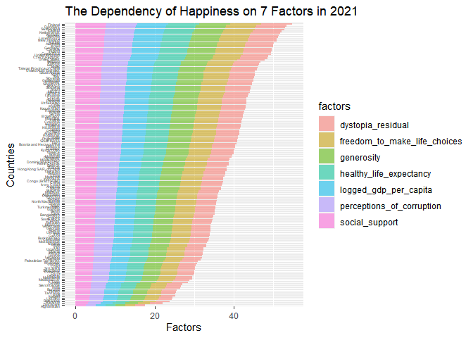

```r
g2<-revamp %>%
  group_by(country_name) %>%
 ggplot(aes(x=reorder(country_name,ladder_score),country_name,y=ladder_score, fill=factors))+
   geom_col(alpha=0.55)+
  coord_flip()+
  labs(title = "The Dependency of Happiness on 7 Factors in 2021", x= "Countries", y="Factors")+
  theme(axis.text.y =element_text(size=3.5))
g2
```

#Slice Max and Min for Revamp(2021) and Reorder(2020) ##Revamp 2021 Max

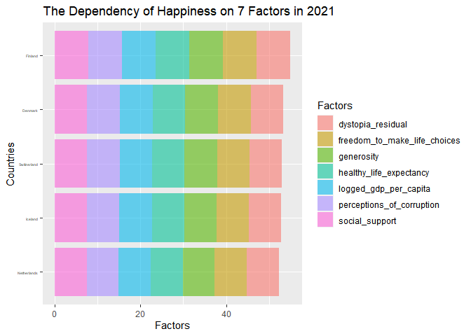

```r
revamp5 <- t1_narrow %>%
  top_n(5,ladder_score) %>%
  group_by(country_name) %>%
pivot_longer (-c(country_name,year,ladder_score),
  names_to= "Factors",
  values_to="Score")

  revamp5 %>%
  ggplot(aes(x=reorder(country_name,ladder_score),country_name,y=ladder_score, fill=Factors))+
   geom_col(alpha=0.59)+
  coord_flip()+
  labs(title = "The Dependency of Happiness on 7 Factors in 2021", x= "Countries", y="Factors")+
  theme(axis.text.y =element_text(size=3.5))
```

```r
revamp5
```

```
## # A tibble: 35 × 5
## # Groups:   country_name [5]
##    country_name ladder_score  year Factors                       Score
##    <chr>               <dbl> <int> <chr>                         <dbl>
##  1 Finland              7.84  2021 social_support                0.954
##  2 Finland              7.84  2021 healthy_life_expectancy      72
##  3 Finland              7.84  2021 freedom_to_make_life_choices  0.949
##  4 Finland              7.84  2021 generosity                   -0.098
##  5 Finland              7.84  2021 perceptions_of_corruption     0.186
##  6 Finland              7.84  2021 logged_gdp_per_capita        10.8
##  7 Finland              7.84  2021 dystopia_residual             3.25
##  8 Denmark              7.62  2021 social_support                0.954
##  9 Denmark              7.62  2021 healthy_life_expectancy      72.7
## 10 Denmark              7.62  2021 freedom_to_make_life_choices  0.946
## # … with 25 more rows
```

##revamp 2021 min

```r
revampbottom5 <- t1_narrow %>%
  top_n(-5,ladder_score) %>%
  group_by(country_name) %>%
pivot_longer (-c(country_name,year,ladder_score),
  names_to= "Factors",
  values_to="Score")
```

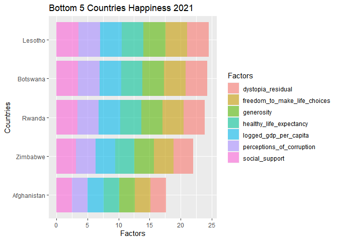

```r
 revampbottom5 %>%
  ggplot(aes(x=reorder(country_name,ladder_score),country_name,y=ladder_score, fill=Factors))+
   geom_col(alpha=0.59)+
  coord_flip()+
  labs(title = "Bottom 5 Countries Happiness 2021", x= "Countries", y="Factors")
```

```r
revampbottom5
```

```
## # A tibble: 35 × 5
## # Groups:   country_name [5]
##    country_name ladder_score  year Factors                       Score
##    <chr>               <dbl> <int> <chr>                         <dbl>
##  1 Lesotho              3.51  2021 social_support                0.787
##  2 Lesotho              3.51  2021 healthy_life_expectancy      48.7
##  3 Lesotho              3.51  2021 freedom_to_make_life_choices  0.715
##  4 Lesotho              3.51  2021 generosity                   -0.131
##  5 Lesotho              3.51  2021 perceptions_of_corruption     0.915
##  6 Lesotho              3.51  2021 logged_gdp_per_capita         7.93
##  7 Lesotho              3.51  2021 dystopia_residual             1.8
##  8 Botswana             3.47  2021 social_support                0.784
##  9 Botswana             3.47  2021 healthy_life_expectancy      59.3
## 10 Botswana             3.47  2021 freedom_to_make_life_choices  0.824
## # … with 25 more rows
```

## reorder max 5

```r
reordermax5 <-tw_narrow %>%
  top_n(5,ladder_score) %>%
  group_by(country_name) %>%
  pivot_longer(-c(country_name, year,ladder_score),
               names_to = "Factors",
               values_to= "Score")
```

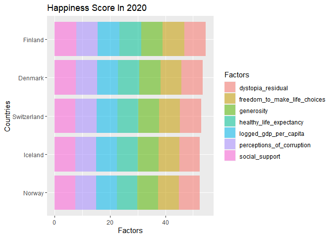

```r
reordermax5 %>%
  ggplot(aes(x= reorder(country_name,ladder_score), country_name, y= ladder_score, fill= Factors))+
  geom_col(alpha =0.55)+
  coord_flip()+
  labs(title = "Happiness Score In 2020", x= "Countries", y= "Factors")
```

```r
reordermin <-tw_narrow %>%
  top_n(-5,ladder_score) %>%
  group_by(country_name) %>%
  pivot_longer(-c(country_name, year,ladder_score),
               names_to = "Factors",
               values_to= "Score")
```

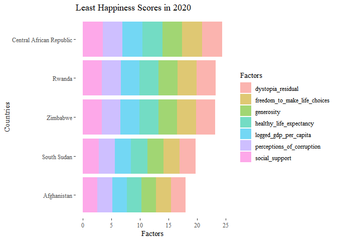

```r
reordermin %>%
  ggplot(aes(x= reorder(country_name,ladder_score), country_name, y= ladder_score, fill= Factors))+
  geom_col(alpha =0.55)+
  coord_flip()+
  labs(title= "Least Happiness Scores in 2020", x= "Countries", y= "Factors")+
  theme_tufte()
```

## analysis for bottom 5 countries ladder scores

```r
tabyl(reordermin$country_name)
```

```
##   reordermin$country_name n percent
##               Afghanistan 7     0.2
##  Central African Republic 7     0.2
##                    Rwanda 7     0.2
##               South Sudan 7     0.2
##                  Zimbabwe 7     0.2
```

```r
tabyl(revampbottom5$country_name)
```

```
##  revampbottom5$country_name n percent
##                 Afghanistan 7     0.2
##                    Botswana 7     0.2
##                     Lesotho 7     0.2
##                      Rwanda 7     0.2
##                    Zimbabwe 7     0.2
```

Similar country names are Afghanistan, Rwanda, and Zimbabwe.

Lesotho went from 11th least happiest country in 2020 to the 5th least happiest country in 2021. Botswana was in 7th least happiest country in 2020 and went to the 4th least happiest country in 2021. Central African Republic was the 5th least happiest country in 2020 and was not listed in the dataset in 2021.

#ladder scores changes from 2020 to 2021

There’s only one data set for Central African Republic

```r
merged_happy %>%
  group_by(year) %>%
  select(country_name, ladder_score, year) %>%
  filter(country_name == "Central African Republic")
```

```
## # A tibble: 1 × 3
## # Groups:   year [1]
##   country_name             ladder_score year
##   <chr>                           <dbl> <chr>
## 1 Central African Republic         3.48 2020
```

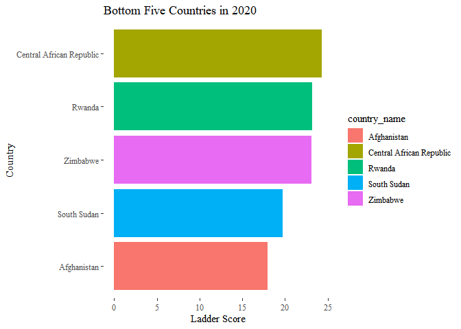

```r
reordermin %>%
  ggplot(aes(x= reorder(country_name,ladder_score), country_name, y= ladder_score, fill= country_name))+
  geom_col()+
  coord_flip()+
   theme_tufte()+
  labs(title= "Bottom Five Countries in 2020", y= "Ladder Score", x = "Country")
```

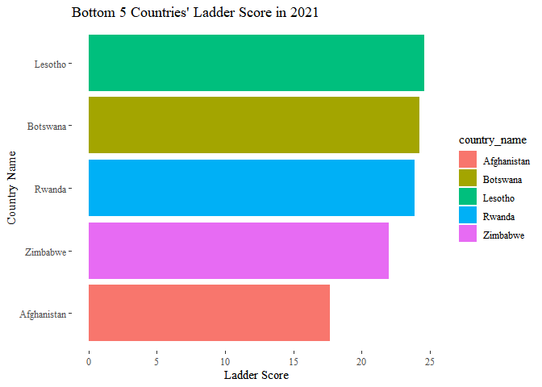

```r
revampbottom5 %>%
  ggplot(aes(x= reorder(country_name,ladder_score), country_name, y= ladder_score, fill = country_name))+
  geom_col()+
  coord_flip()+
  theme_tufte()+
  labs(title= "Bottom 5 Countries' Ladder Score in 2021", y= "Ladder Score", x= "Country Name")
```

```r
n_bottom_happy <-n_happy %>%
  top_n(-30, ladder_score)
n_bottom_happy %>%
  group_by(country_name)
```

```
## # A tibble: 30 × 21
## # Groups:   country_name [17]
##    country_name region…¹ ladde…² stand…³ upper…⁴ lower…⁵ logge…⁶ socia…⁷ healt…⁸
##    <chr>        <chr>      <dbl>   <dbl>   <dbl>   <dbl>   <dbl>   <dbl>   <dbl>
##  1 Togo         Sub-Sah…    4.11   0.077    4.26    3.96    7.36   0.569    54.9
##  2 Zambia       Sub-Sah…    4.07   0.069    4.21    3.94    8.14   0.708    55.8
##  3 Sierra Leone Sub-Sah…    3.85   0.077    4.00    3.70    7.43   0.63     51.7
##  4 India        South A…    3.82   0.026    3.87    3.77    8.76   0.603    60.6
##  5 Burundi      Sub-Sah…    3.78   0.107    3.98    3.56    6.64   0.49     53.4
##  6 Yemen        Middle …    3.66   0.07     3.79    3.52    7.58   0.832    57.1
##  7 Tanzania     Sub-Sah…    3.62   0.071    3.76    3.48    7.88   0.702    58.0
##  8 Haiti        Latin A…    3.62   0.173    3.95    3.28    7.48   0.54     55.7
##  9 Malawi       Sub-Sah…    3.6    0.092    3.78    3.42    6.96   0.537    57.9
## 10 Lesotho      Sub-Sah…    3.51   0.12     3.75    3.28    7.93   0.787    48.7
## # … with 20 more rows, 12 more variables: freedom_to_make_life_choices <dbl>,
## #   generosity <dbl>, perceptions_of_corruption <dbl>,
## #   ladder_score_in_dystopia <dbl>, explained_by_log_gdp_per_capita <dbl>,
## #   explained_by_social_support <dbl>,
## #   explained_by_healthy_life_expectancy <dbl>,
## #   explained_by_freedom_to_make_life_choices <dbl>,
## #   explained_by_generosity <dbl>, …
```

Similar country names are Afghanistan, Rwanda, and Zimbabwe.

Lesotho went from 11th least happiest country in 2020 to the 5th least happiest country in 2021. Botswana was in 7th least happiest country in 2020 and went to the 4th least happiest country in 2021. Central African Republic was the 5th least happiest country in 2020 and was not listed in the dataset in 2021. South Sudan was 2nd most least happiest country in 2020 but not listed in the dataset in 2021.

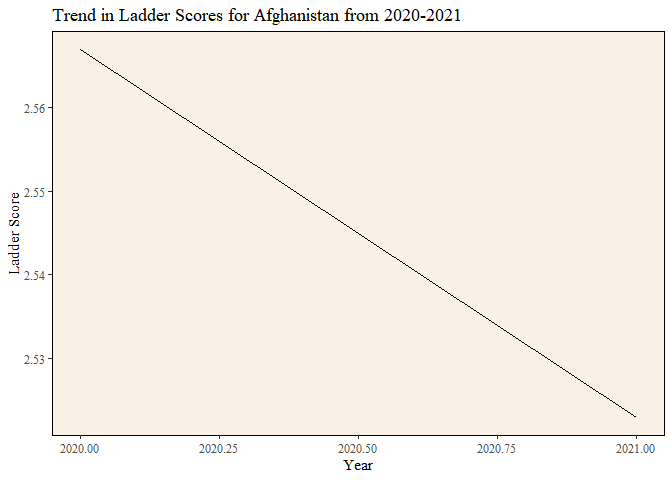

```r
least_happy <- n_bottom_happy %>%
 group_by(year) %>%
  filter(country_name=="Afghanistan") %>%
  ggplot(aes(x=year,y=ladder_score))+
  geom_line()+
      theme_tufte()+
        theme(panel.background = element_rect(fill = "linen"))+
  labs(x = "Year", y = "Ladder Score",title="Trend in Ladder Scores for Afghanistan from 2020-2021")
least_happy
```

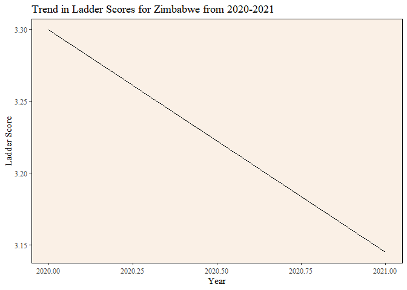

```r
second_least_happy <-n_bottom_happy %>%
group_by(year) %>%
  filter(country_name=="Zimbabwe") %>%
  ggplot(aes(x=year,y=ladder_score))+
  geom_line()+
      theme_tufte()+
        theme(panel.background = element_rect(fill = "linen"))+
  labs(x = "Year", y = "Ladder Score",title="Trend in Ladder Scores for Zimbabwe from 2020-2021")
second_least_happy
```

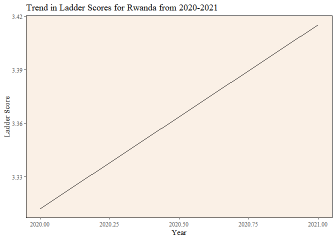

```r
third_least_happy <-n_bottom_happy %>%
  group_by(year) %>%
  filter(country_name=="Rwanda") %>%
  ggplot(aes(x=year,y=ladder_score))+
  geom_line()+
      theme_tufte()+
        theme(panel.background = element_rect(fill = "linen"))+
  labs(x = "Year", y = "Ladder Score",title="Trend in Ladder Scores for Rwanda from 2020-2021")
third_least_happy
```

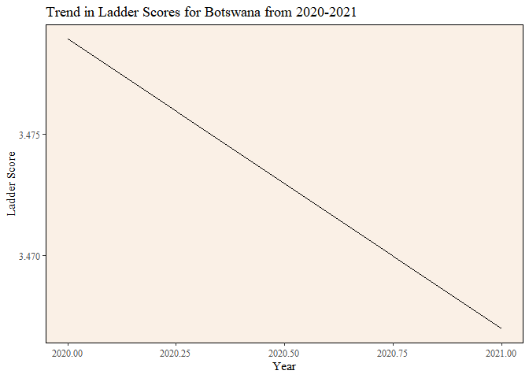

```r
fourth_least_happy <-n_bottom_happy %>%
  group_by(year) %>%
  filter(country_name=="Botswana") %>%
  ggplot(aes(x=year,y=ladder_score))+
  geom_line()+
      theme_tufte()+
        theme(panel.background = element_rect(fill = "linen"))+
  labs(x = "Year", y = "Ladder Score",title="Trend in Ladder Scores for Botswana from 2020-2021")
fourth_least_happy
```

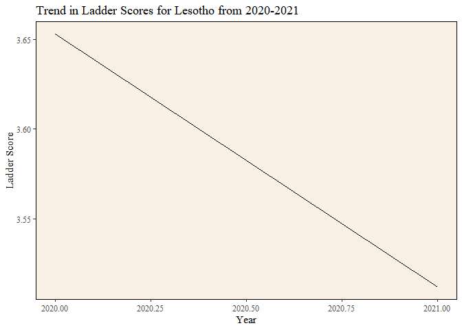

```r
fifth_least_happy <-n_bottom_happy %>%
  group_by(year) %>%
  filter(country_name=="Lesotho") %>%
  ggplot(aes(x=year,y=ladder_score))+
  geom_line()+
      theme_tufte()+
        theme(panel.background = element_rect(fill = "linen"))+
  labs(x = "Year", y = "Ladder Score",title="Trend in Ladder Scores for Lesotho from 2020-2021")
fifth_least_happy
```

pivoting datasets to wider:

```r
bottom_5_2020 <- reordermin %>%
  pivot_wider(names_from = "Factors",
              values_from= "Score")
```

```r
bottom5_2021 <-revampbottom5 %>%
  pivot_wider(names_from = "Factors",
              values_from= "Score")
```

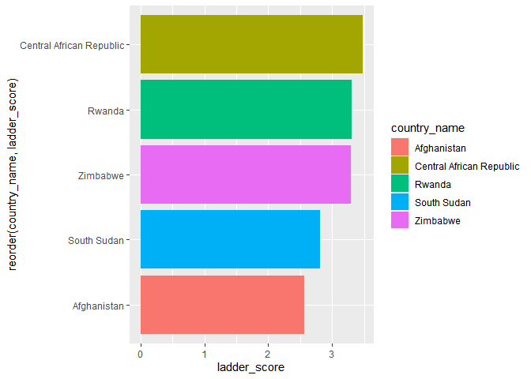

```r
bottom_5_2020 %>%
  ggplot(aes(x= reorder(country_name,ladder_score),country_name, y= ladder_score, fill= country_name))+
  geom_col()+
  coord_flip()
```

# Social Support for 2020 and 2021

```r
names(n_bottom_happy)
```

```
##  [1] "country_name"
##  [2] "regional_indicator"
##  [3] "ladder_score"
##  [4] "standard_error_of_ladder_score"
##  [5] "upperwhisker"
##  [6] "lowerwhisker"
##  [7] "logged_gdp_per_capita"
##  [8] "social_support"
##  [9] "healthy_life_expectancy"
## [10] "freedom_to_make_life_choices"
## [11] "generosity"
## [12] "perceptions_of_corruption"
## [13] "ladder_score_in_dystopia"
## [14] "explained_by_log_gdp_per_capita"
## [15] "explained_by_social_support"
## [16] "explained_by_healthy_life_expectancy"
## [17] "explained_by_freedom_to_make_life_choices"
## [18] "explained_by_generosity"
## [19] "explained_by_perceptions_of_corruption"
## [20] "dystopia_residual"
## [21] "year"
```

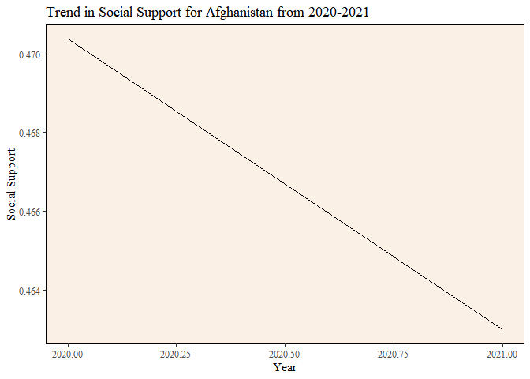

```r
social_support_afghanistan <- n_bottom_happy %>%
 group_by(year) %>%
  filter(country_name=="Afghanistan") %>%
  ggplot(aes(x=year,y= social_support))+
  geom_line()+
      theme_tufte()+
        theme(panel.background = element_rect(fill = "linen"))+
  labs(x = "Year", y = "Social Support",title="Trend in Social Support for Afghanistan from 2020-2021")
social_support_afghanistan
```

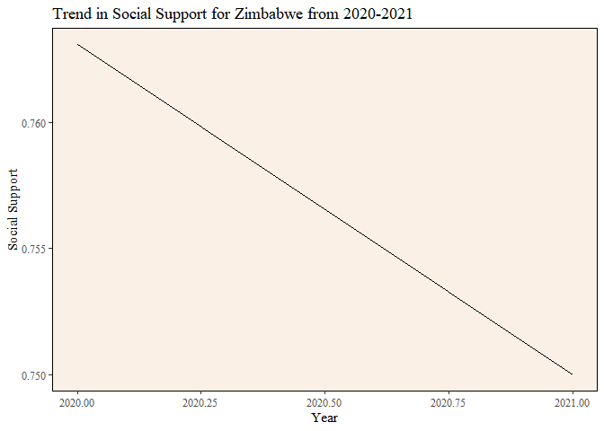

```r
social_support_zimbabwe <- n_bottom_happy %>%
 group_by(year) %>%
  filter(country_name=="Zimbabwe") %>%
  ggplot(aes(x=year,y= social_support))+
  geom_line()+
      theme_tufte()+
        theme(panel.background = element_rect(fill = "linen"))+
  labs(x = "Year", y = "Social Support",title="Trend in Social Support for Zimbabwe from 2020-2021")
social_support_zimbabwe
```

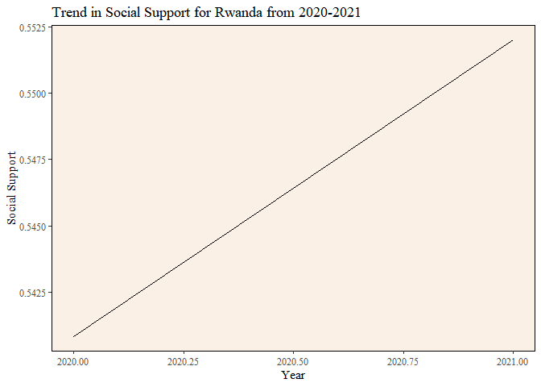

```r
social_support_rwanda <- n_bottom_happy %>%
 group_by(year) %>%
  filter(country_name=="Rwanda") %>%
  ggplot(aes(x=year,y= social_support))+
  geom_line()+
      theme_tufte()+
        theme(panel.background = element_rect(fill = "linen"))+
  labs(x = "Year", y = "Social Support",title="Trend in Social Support for Rwanda from 2020-2021")
social_support_rwanda
```

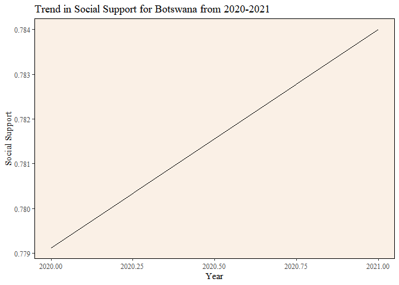

```r
social_support_botswana <- n_bottom_happy %>%
 group_by(year) %>%
  filter(country_name=="Botswana") %>%
  ggplot(aes(x=year,y= social_support))+
  geom_line()+
      theme_tufte()+
        theme(panel.background = element_rect(fill = "linen"))+
  labs(x = "Year", y = "Social Support",title="Trend in Social Support for Botswana from 2020-2021")
social_support_botswana
```

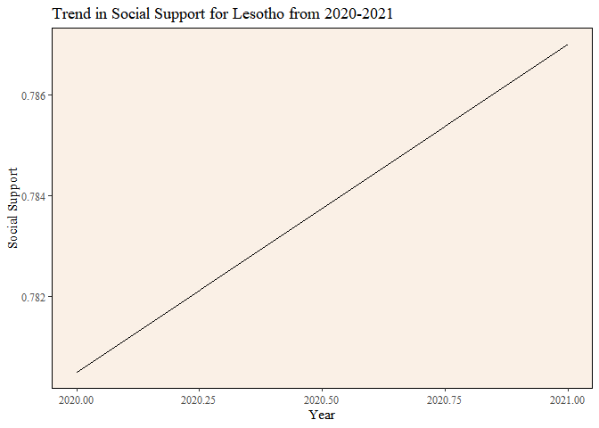

```r
social_support_lesotho <- n_bottom_happy %>%
 group_by(year) %>%
  filter(country_name=="Lesotho") %>%
  ggplot(aes(x=year,y= social_support))+
  geom_line()+
      theme_tufte()+
        theme(panel.background = element_rect(fill = "linen"))+
  labs(x = "Year", y = "Social Support",title="Trend in Social Support for Lesotho from 2020-2021")
social_support_lesotho
```

## Life Expectancy changes in bottom 5 countries from 2020-2021

```r
names(n_bottom_happy)
```

```
##  [1] "country_name"
##  [2] "regional_indicator"
##  [3] "ladder_score"
##  [4] "standard_error_of_ladder_score"
##  [5] "upperwhisker"
##  [6] "lowerwhisker"
##  [7] "logged_gdp_per_capita"
##  [8] "social_support"
##  [9] "healthy_life_expectancy"
## [10] "freedom_to_make_life_choices"
## [11] "generosity"
## [12] "perceptions_of_corruption"
## [13] "ladder_score_in_dystopia"
## [14] "explained_by_log_gdp_per_capita"
## [15] "explained_by_social_support"
## [16] "explained_by_healthy_life_expectancy"
## [17] "explained_by_freedom_to_make_life_choices"
## [18] "explained_by_generosity"
## [19] "explained_by_perceptions_of_corruption"
## [20] "dystopia_residual"
## [21] "year"
```

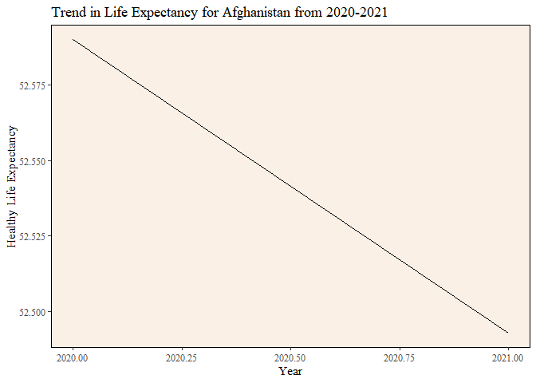

```r
life_expectancy_afghanistan <- n_bottom_happy %>%
 group_by(year) %>%
  filter(country_name=="Afghanistan") %>%
  ggplot(aes(x=year,y= healthy_life_expectancy))+
  geom_line()+
      theme_tufte()+
        theme(panel.background = element_rect(fill = "linen"))+
  labs(x = "Year", y = "Healthy Life Expectancy",title="Trend in Life Expectancy for Afghanistan from 2020-2021")
life_expectancy_afghanistan
```

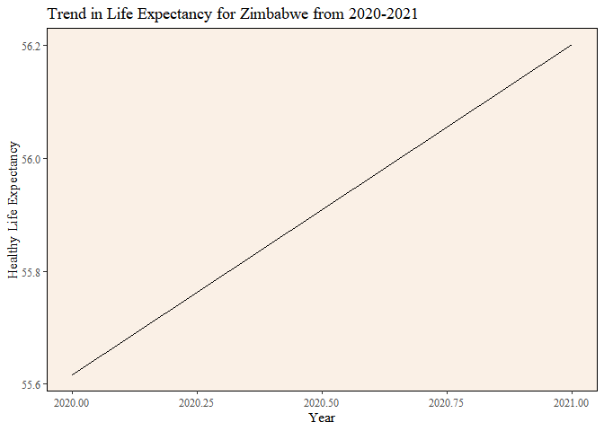

```r
life_expectancy_zimbabwe <- n_bottom_happy %>%
 group_by(year) %>%
  filter(country_name=="Zimbabwe") %>%
  ggplot(aes(x=year,y= healthy_life_expectancy))+
  geom_line()+
      theme_tufte()+
        theme(panel.background = element_rect(fill = "linen"))+
  labs(x = "Year", y = "Healthy Life Expectancy",title="Trend in Life Expectancy for Zimbabwe from 2020-2021")
life_expectancy_zimbabwe
```

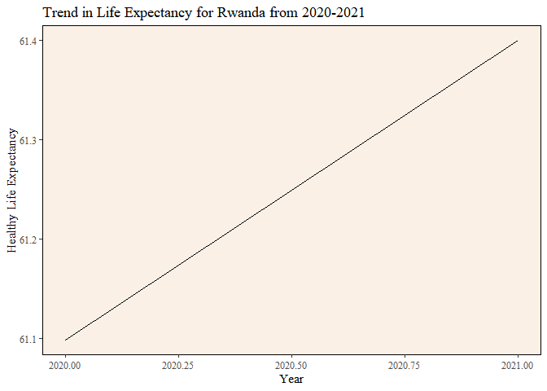

```r
life_expectancy_rwanda <- n_bottom_happy %>%
 group_by(year) %>%
  filter(country_name=="Rwanda") %>%
  ggplot(aes(x=year,y= healthy_life_expectancy))+
  geom_line()+
      theme_tufte()+
        theme(panel.background = element_rect(fill = "linen"))+
  labs(x = "Year", y = "Healthy Life Expectancy",title="Trend in Life Expectancy for Rwanda from 2020-2021")
life_expectancy_rwanda
```

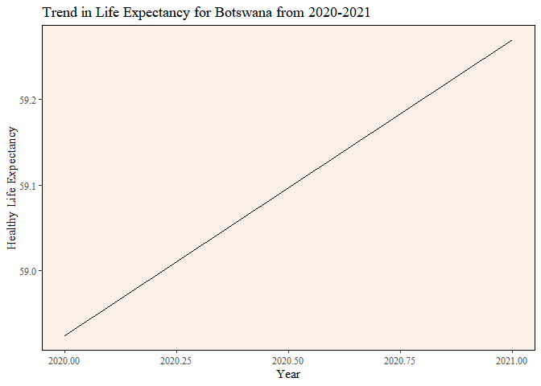

```r
life_expectancy_botswana <- n_bottom_happy %>%
 group_by(year) %>%
  filter(country_name=="Botswana") %>%
  ggplot(aes(x=year,y= healthy_life_expectancy))+
  geom_line()+
      theme_tufte()+
        theme(panel.background = element_rect(fill = "linen"))+
  labs(x = "Year", y = "Healthy Life Expectancy",title="Trend in Life Expectancy for Botswana from 2020-2021")
life_expectancy_botswana
```

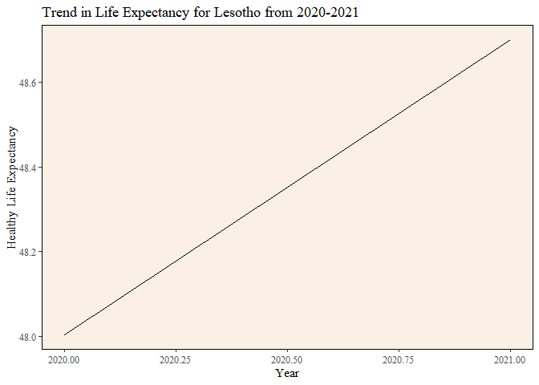

```r
life_expectancy_lesotho <- n_bottom_happy %>%
 group_by(year) %>%
  filter(country_name=="Lesotho") %>%
  ggplot(aes(x=year,y= healthy_life_expectancy))+
  geom_line()+
      theme_tufte()+
        theme(panel.background = element_rect(fill = "linen"))+
  labs(x = "Year", y = "Healthy Life Expectancy",title="Trend in Life Expectancy for Lesotho from 2020-2021")
life_expectancy_lesotho
```

## statistical analysis of the 3 factors selected: ladder score, life expectancy, and social support

```r
n_bottom_happy_ladder_score <-n_bottom_happy %>%
  select(country_name, ladder_score, year)

n_bottom_happy_ladder_score
```

```
##                country_name ladder_score year
## 1                      Togo       4.1070 2021
## 2                    Zambia       4.0730 2021
## 3              Sierra Leone       3.8490 2021
## 4                     India       3.8190 2021
## 5                   Burundi       3.7750 2021
## 6                     Yemen       3.6580 2021
## 7                  Tanzania       3.6230 2021
## 8                     Haiti       3.6150 2021
## 9                    Malawi       3.6000 2021
## 10                  Lesotho       3.5120 2021
## 11                 Botswana       3.4670 2021
## 12                   Rwanda       3.4150 2021
## 13                 Zimbabwe       3.1450 2021
## 14              Afghanistan       2.5230 2021
```

[output cut: 16 more lines]

```r
n_bottom_happy_ladder_score<-n_bottom_happy_ladder_score %>%
  pivot_wider(names_from= "year", names_prefix = "yr_", values_from = ladder_score)
```

```r
n_bottom_happy_ladder_score <- n_bottom_happy_ladder_score %>%
  select(country_name, yr_2020, yr_2021)
n_bottom_happy_ladder_score
```

```
## # A tibble: 17 × 3
##    country_name             yr_2020 yr_2021
##    <chr>                      <dbl>   <dbl>
##  1 Togo                       NA       4.11
##  2 Zambia                      3.76    4.07
##  3 Sierra Leone                3.93    3.85
##  4 India                       3.57    3.82
##  5 Burundi                     3.78    3.78
##  6 Yemen                       3.53    3.66
##  7 Tanzania                    3.48    3.62
##  8 Haiti                       3.72    3.62
##  9 Malawi                      3.54    3.6
## 10 Lesotho                     3.65    3.51
## 11 Botswana                    3.48    3.47
## 12 Rwanda                      3.31    3.42
## 13 Zimbabwe                    3.30    3.14
## 14 Afghanistan                 2.57    2.52
## 15 Egypt                       4.15   NA
## 16 Central African Republic    3.48   NA
## 17 South Sudan                 2.82   NA
```

```r
n_bottom_happy_ladder_score %>%
  mutate(perc_change_ladder_score = (yr_2021-yr_2020)/(yr_2020)*100) %>%
  arrange((perc_change_ladder_score))
```

```
## # A tibble: 17 × 4
##    country_name             yr_2020 yr_2021 perc_change_ladder_score
##    <chr>                      <dbl>   <dbl>                    <dbl>
##  1 Zimbabwe                    3.30    3.14                 -4.67
##  2 Lesotho                     3.65    3.51                 -3.85
##  3 Haiti                       3.72    3.62                 -2.84
##  4 Sierra Leone                3.93    3.85                 -1.97
##  5 Afghanistan                 2.57    2.52                 -1.71
##  6 Botswana                    3.48    3.47                 -0.342
##  7 Burundi                     3.78    3.78                 -0.00795
##  8 Malawi                      3.54    3.6                   1.75
##  9 Rwanda                      3.31    3.42                  3.10
## 10 Yemen                       3.53    3.66                  3.70
## 11 Tanzania                    3.48    3.62                  4.22
## 12 India                       3.57    3.82                  6.88
## 13 Zambia                      3.76    4.07                  8.34
## 14 Togo                       NA       4.11                 NA
## 15 Egypt                       4.15   NA                    NA
## 16 Central African Republic    3.48   NA                    NA
## 17 South Sudan                 2.82   NA                    NA
```

The one with the greatest decrease in ladder score from the most unhappiest countries from 2020 to 2021 is Zimbabwe (coming from 3rd place in 2020 to 2nd place in 2021). The one with the greatest increase in ladder score in the most unhappiest countries from 2020 to 2021 is Zambia with an 8.3% increase.

For the ones with the least happiest ladder scores: Afghanistan decreased in ladder score by -1.71% South Sudan had no data in 2021 so NA for percent change Zimbabwe decreased in ladder score by -4.67%. Rwanda increased in ladder score by 3.1% Central African Republic had no data in 2021, so NA for percent change Botswana decreased in ladder score by -0.34%. Lesotho decreased in ladder score by -3.85%

```r
n_bottom_happy_life_expectancy <-n_bottom_happy %>%
  select(country_name, healthy_life_expectancy, year)

n_bottom_happy_life_expectancy
```

```
##                country_name healthy_life_expectancy year
## 1                      Togo                54.91400 2021
## 2                    Zambia                55.80900 2021
## 3              Sierra Leone                51.65100 2021
## 4                     India                60.63300 2021
## 5                   Burundi                53.40000 2021
## 6                     Yemen                57.12200 2021
## 7                  Tanzania                57.99900 2021
## 8                     Haiti                55.70000 2021
## 9                    Malawi                57.94800 2021
## 10                  Lesotho                48.70000 2021
## 11                 Botswana                59.26900 2021
## 12                   Rwanda                61.40000 2021
## 13                 Zimbabwe                56.20100 2021
## 14              Afghanistan                52.49300 2021
```

[output cut: 16 more lines]

```r
n_bottom_happy_life_expectancy <-n_bottom_happy_life_expectancy  %>%
  pivot_wider(names_from= year,names_prefix = "yr_",  values_from = healthy_life_expectancy)
```

```r
n_bottom_happy_life_expectancy <- n_bottom_happy_life_expectancy %>%
  select(country_name, yr_2020, yr_2021)
```

```r
n_bottom_happy_life_expectancy %>%
  mutate(perc_change_life_exp = (yr_2021-yr_2020)/(yr_2020)*100) %>%
  arrange(perc_change_life_exp)
```

```
## # A tibble: 17 × 4
##    country_name             yr_2020 yr_2021 perc_change_life_exp
##    <chr>                      <dbl>   <dbl>                <dbl>
##  1 Afghanistan                 52.6    52.5          -0.184
##  2 Burundi                     53.4    53.4          -0.00000287
##  3 Haiti                       55.6    55.7           0.182
##  4 Rwanda                      61.1    61.4           0.493
##  5 Botswana                    58.9    59.3           0.585
##  6 Malawi                      57.6    57.9           0.617
##  7 India                       60.2    60.6           0.694
##  8 Yemen                       56.7    57.1           0.696
##  9 Tanzania                    57.5    58.0           0.875
## 10 Zambia                      55.3    55.8           0.922
## 11 Zimbabwe                    55.6    56.2           1.05
## 12 Lesotho                     48.0    48.7           1.45
## 13 Sierra Leone                50.9    51.7           1.54
## 14 Togo                        NA      54.9          NA
## 15 Egypt                       61.8    NA            NA
## 16 Central African Republic    45.2    NA            NA
## 17 South Sudan                 51      NA            NA
```

The country that decreased the most in healthy life expectancy is Afghanistan and the one that increased the most in healthy life expectancy is Sierra Leone. No information was found for Togo, Egypt, Central African Republic or South Sudan since they had no data in either one or the other datasets in 2020 or 2021.

For the ones with the least happiest countries’ ladder scores:

Afghanistan decreased in healthy life expectancy by -1.84*10^-1% South Sudan had no data in 2021, so NA for percent change for life expectancy Zimbabwe increased in life expectancy by 1.049% Rwanda increased in life expectancy by 4.92*10^-1%. Central African Republic had no data in 2021, so NA for percent change in life expectancy Botswana increased in life expectancy by 5.84x10^-1% Lesotho increased in life expectancy by 1.45%

```r
n_bottom_social_support <-n_bottom_happy %>%
  select(country_name, social_support, year)
n_bottom_social_support
```

```
##                country_name social_support year
## 1                      Togo      0.5690000 2021
## 2                    Zambia      0.7080000 2021
## 3              Sierra Leone      0.6300000 2021
## 4                     India      0.6030000 2021
## 5                   Burundi      0.4900000 2021
## 6                     Yemen      0.8320000 2021
## 7                  Tanzania      0.7020000 2021
## 8                     Haiti      0.5400000 2021
## 9                    Malawi      0.5370000 2021
## 10                  Lesotho      0.7870000 2021
## 11                 Botswana      0.7840000 2021
## 12                   Rwanda      0.5520000 2021
## 13                 Zimbabwe      0.7500000 2021
## 14              Afghanistan      0.4630000 2021
```

[output cut: 16 more lines]

```r
n_bottom_social_support <- n_bottom_social_support %>%
  pivot_wider(names_from = year,names_prefix = "yr_",  values_from = social_support)
```

```r
n_bottom_social_support <- n_bottom_social_support %>%
  select(country_name, yr_2020, yr_2021)
```

```r
n_bottom_social_support %>%
  mutate(percentchange_soc_sup = (yr_2021-yr_2020)/(yr_2020)*100) %>%
  arrange(percentchange_soc_sup)
```

```
## # A tibble: 17 × 4
##    country_name             yr_2020 yr_2021 percentchange_soc_sup
##    <chr>                      <dbl>   <dbl>                 <dbl>
##  1 Haiti                      0.593   0.54                -8.98
##  2 Zimbabwe                   0.763   0.75                -1.72
##  3 Afghanistan                0.470   0.463               -1.57
##  4 Malawi                     0.544   0.537               -1.29
##  5 Sierra Leone               0.636   0.63                -0.966
##  6 Burundi                    0.490   0.49                -0.0664
##  7 Botswana                   0.779   0.784                0.626
##  8 Lesotho                    0.780   0.787                0.833
##  9 Zambia                     0.699   0.708                1.31
## 10 Yemen                      0.818   0.832                1.71
## 11 India                      0.592   0.603                1.82
## 12 Tanzania                   0.689   0.702                1.90
## 13 Rwanda                     0.541   0.552                2.06
## 14 Togo                      NA       0.569               NA
## 15 Egypt                      0.735  NA                   NA
## 16 Central African Republic   0.319  NA                   NA
## 17 South Sudan                0.554  NA                   NA
```

Out of the least unhappiest countries, the one that had the most decrease in social support was Haiti, decreased by -8.97% from 2020 to 2021 and the one that had the most increase in social support was Rwanda with 2.06%.

Out of the least happiest countries in 2020 and 2021: Afghanistan: decreased in social support by -1.56% South Sudan: no info in 2021, NA for percent change in social support Zimbabwe Rwanda: increased in social support by 2.06% Central African Republic: no info in 2021, NA for percent change in social support Botswana: increased in social support by 0.62% Lesotho: Increased in social support by 0.833%